# AN588 Homework 4 (Fall 2023)

Jess Martin

10/25/2023

# Question #1

**Write a simple R function, Z.prop.test(), that can perform one- or two-sample Z-tests for proportion data, using the following guidelines:**

- Your function should take the following arguments: p1 and n1 (no default) representing the estimated proportion and sample size (i.e., based on your sample data); p2 and n2 (both defaulting to NULL) that contain a second sample’s proportion and sample size data in the event of a two-sample test; p0 (no default) as the expected value for the population proportion; and alternative (default “two.sided”) and conf.level (default 0.95), to be used in the same way as in the function t.test().
- When conducting a two-sample test, it should be p1 that is tested as being smaller or larger than p2 when alternative=“less” or alternative=“greater”, the same as in the use of x and y in the function t.test().
- The function should perform a one-sample Z-test using p1, n1, and p0 if either p2 or n2 (or both) is NULL.
- The function should contain a check for the rules of thumb we have talked about (n∗p>5 and n∗(1−p)>5) to ensure the validity of assuming the normal distribution in both the one- and two-sample settings. If this is violated, the function should still complete but it should also print an appropriate warning message.
- The function should return a list containing the members Z (the test statistic), P (the appropriate p value), and CI (the two-sided CI with respect to “conf.level” around p1 in the case of a one-sample test and around p2-p1 in the case of a two-sample test). For all test alternatives (“two.sided”, “greater”, “less”), calculate symmetric CIs based on quantiles of the normal distribution rather than worrying about calculating single-limit confidence bounds.

```r
Z.prop.test <- function(p0, p1, n1, p2 = NULL, n2 = NULL, alternative = "two.sided", conf.level = 0.95)
{
  # One sample Z-test
 if (is.null(p2) | is.null(n2)) {
   z <- (p1 - p0)/sqrt(p0*(1 - p0) / n1) #one sample z test
   if (alternative == "greater") {p <- pnorm(z, lower.tail = FALSE)}
   if (alternative == "less") {p <- pnorm(z, lower.tail = TRUE)}
   if (alternative == "two.sided") {
          if (z > 0) {
            pval <- 2 * pnorm(z, lower.tail = FALSE)
          }
          if (z < 0) {
            pval <- 2 * pnorm(z, lower.tail = TRUE)
          }}
    if ((n1 * p0 < 5) | (n1 * (1 - p0) < 5 )) {
      warning("Check data, assumption of normal distribution violated!")
    }

    upper <- p1 - qnorm(1 - conf.level / 2) * sqrt(p1 * (1 - p1) / n1)
    lower <- p1 + qnorm(1 - conf.level / 2) * sqrt(p1 * (1 - p1) / n1)
    ci <- c(lower, upper)

    result <- list(Z = z, P = pval, CI = ci)
    return(result)
 }
  # Two sample Z-test
 else {
    pstar <- ((p1*n1) + (p2*n2))/(n1 + n2)
    z <- (p2 - p1)/sqrt((pstar * (1 - pstar)) * (1/n1 + 1/n2))
    if (alternative == "greater") {
        pval <- pnorm(z, lower.tail = FALSE)
      }
      if (alternative == "less") {
        pval <- pnorm(z, lower.tail = TRUE)
      }
      if (alternative == "two.sided") {
          if (z > 0) {
            pval <- 2 * pnorm(z, lower.tail = FALSE)
          }
          if (z < 0) {
            pval <- 2 * pnorm(z, lower.tail = TRUE)
          }}
    if ((n1 * p1 > 5) | (n1 * (1 - p1) > 5) | (n2 * p2 > 5) | (n2 * (1 - p2) > 5)) {
      warning("Check data, assumption of normal distribution violated!")
    }

    se <- sqrt(pstar * (1-pstar) * (1/n1 + 1/n2))
    upper <- (p2-p1) + qnorm(1 - (1 - conf.level)/2) * se
    lower <- (p2-p1) + qnorm((1 - conf.level)/2) * se
    ci <- c(lower, upper)

    result <- list(Z = z, P = pval, CI = ci)
    return(result)
  }
}
```

# Question #2

**The dataset from Kamilar and Cooper has in it a large number of variables related to life history and body size. For this exercise, the end aim is to fit a simple linear regression model to predict longevity (MaxLongevity_m) measured in months from species’ brain size (Brain_Size_Species_Mean) measured in grams. Do the following for both longevity~brain size and log(longevity)~log(brain size):**

```r
# Load Relevant Packages
library(ggplot2)
library(curl)
```

```r
# Load Relevant Dataset
f <- curl("https://raw.githubusercontent.com/fuzzyatelin/fuzzyatelin.github.io/master/AN588_Fall23/KamilarAndCooperData.csv")
d <- read.csv(f, header = TRUE, sep = ",", stringsAsFactors = FALSE)
head(d)
```

```
##               Scientific_Name          Family          Genus      Species
## 1 Allenopithecus_nigroviridis Cercopithecidae Allenopithecus nigroviridis
## 2         Allocebus_trichotis Cercopithecidae      Allocebus    trichotis
## 3           Alouatta_belzebul        Atelidae       Alouatta     belzebul
## 4             Alouatta_caraya        Atelidae       Alouatta       caraya
## 5            Alouatta_guariba        Atelidae       Alouatta      guariba
## 6           Alouatta_palliata        Atelidae       Alouatta     palliata
##   Brain_Size_Species_Mean Brain_Size_Female_Mean   Brain_size_Ref
## 1                   58.02                  53.70 Isler et al 2008
## 2                      NA                     NA
## 3                   52.84                  51.19 Isler et al 2008
## 4                   52.63                  47.80 Isler et al 2008
## 5                   51.70                  49.08 Isler et al 2008
## 6                   49.88                  48.04 Isler et al 2008
##   Body_mass_male_mean Body_mass_female_mean Mass_Dimorphism
```

[output cut: 62 more lines]

## Longevity~Brain Size

```r
d <- na.omit(d)
l <- d$MaxLongevity_m
b <- d$Brain_Size_Species_Mean
```

- Fit the regression model and, using {ggplot2}, produce a scatterplot with the fitted line superimposed upon the data. Append the the fitted model equation to your plot (HINT: use the function geom_text()).

```r
beta1 <- cor(l, b) * sd(l)/sd(b)
beta1
```

```
## [1] 0.8789037
```

```r
beta0 <- mean(l) - beta1 * mean(b)
beta0
```

```
## [1] 307.7522
```

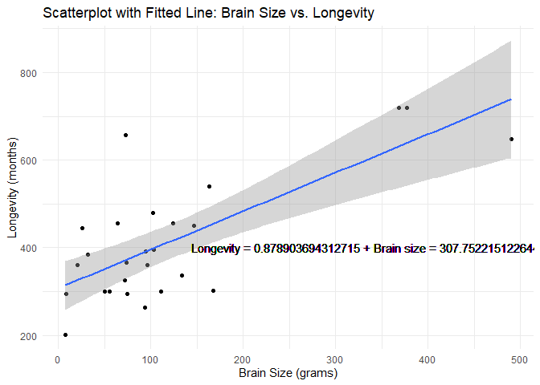

```r
g <- ggplot(data = d, aes(x = b, y = l)) +
  geom_point() +
  geom_smooth(method = "lm") +
  labs(title = "Scatterplot with Fitted Line: Brain Size vs. Longevity",
       x = "Brain Size (grams)", y = "Longevity (months)") +
  theme_minimal()

equation <- paste("Longevity = ", beta1, " + ","Brain size = ", beta0, " + ", sep = "")

g + geom_text(x = 340, y = 400, label = equation)
```

- Identify and interpret the point estimate of the slope (β1), as well as the outcome of the test associated with the hypotheses H0: β1 = 0; HA: β1 ≠ 0. Also, find a 90 percent CI for the slope (β1) parameter.

We reject the null hypothesis (HA: β1 ≠ 0) in favor of the alternative hypothesis. There is a strong association between brain size and longevity- as brain size increases, longevity increases too.

```r
m <- lm(l ~ b, data = d)
m
```

```
##
## Call:
## lm(formula = l ~ b, data = d)
##
## Coefficients:
## (Intercept)            b
##    307.7522       0.8789
```

```r
ci <- confint(m, level = 0.90)
ci
```

```
##                     5 %       95 %
## (Intercept) 260.1112167 355.393214
## b             0.5928154   1.164992
```

- Using your model, add lines for the 90 percent confidence and prediction interval bands on the plot and add a legend to differentiate between the lines.

```r
ci <- predict(m, newdata = data.frame(b = d$b), interval = "confidence", level = 0.90)
head(ci)
```

```
##        fit      lwr      upr
## 1 351.5919 312.9621 390.2217
## 2 356.2853 318.4280 394.1425
## 3 314.1155 267.9467 360.2843
## 4 371.8507 336.2051 407.4962
## 5 370.4444 334.6229 406.2659
## 6 373.1339 337.6445 408.6232
```

```r
pi <- predict(m, newdata = data.frame(b = d$b), interval = "prediction", level = 0.90)
head(pi)
```

```
##        fit      lwr      upr
## 1 351.5919 179.0151 524.1688
## 2 356.2853 183.8797 528.6908
## 3 314.1155 139.6963 488.5347
## 4 371.8507 199.9172 543.7841
## 5 370.4444 198.4744 542.4144
## 6 373.1339 201.2328 545.0350
```

```r
df <- data.frame(cbind(ci, l, b, pi))
head(df)
```

```
##        fit      lwr      upr     l     b    fit.1    lwr.1    upr.1
## 1 351.5919 312.9621 390.2217 300.0 49.88 351.5919 179.0151 524.1688
## 2 356.2853 318.4280 394.1425 300.0 55.22 356.2853 183.8797 528.6908
## 3 314.1155 267.9467 360.2843 201.6  7.24 314.1155 139.6963 488.5347
## 4 371.8507 336.2051 407.4962 657.6 72.93 371.8507 199.9172 543.7841
## 5 370.4444 334.6229 406.2659 325.2 71.33 370.4444 198.4744 542.4144
## 6 373.1339 337.6445 408.6232 294.0 74.39 373.1339 201.2328 545.0350
```

```r
names(df) <- c("l", "b", "CIfit", "CIlwr", "CIupr", "PIfit", "PIlwr", "PIupr")
head(df)
```

```
##          l        b    CIfit CIlwr CIupr    PIfit    PIlwr    PIupr
## 1 351.5919 312.9621 390.2217 300.0 49.88 351.5919 179.0151 524.1688
## 2 356.2853 318.4280 394.1425 300.0 55.22 356.2853 183.8797 528.6908
## 3 314.1155 267.9467 360.2843 201.6  7.24 314.1155 139.6963 488.5347
## 4 371.8507 336.2051 407.4962 657.6 72.93 371.8507 199.9172 543.7841
## 5 370.4444 334.6229 406.2659 325.2 71.33 370.4444 198.4744 542.4144
## 6 373.1339 337.6445 408.6232 294.0 74.39 373.1339 201.2328 545.0350
```

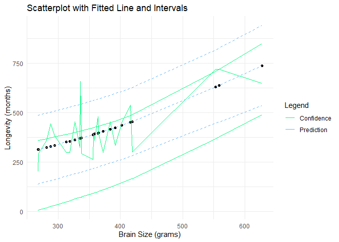

```r
g <- ggplot(data = df, aes(x = b, y = l)) +
  geom_point() +
  geom_line(aes(x = b, y = CIfit, color = "Confidence"), linetype = "solid") +
  geom_line(aes(x = b, y = CIlwr, color = "Confidence"), linetype = "solid") +
  geom_line(aes(x = b, y = CIupr, color = "Confidence"), linetype = "solid") +
  geom_line(aes(x = b, y = PIfit, color = "Prediction"), linetype = "dashed") +
  geom_line(aes(x = b, y = PIlwr, color = "Prediction"), linetype = "dashed") +
  geom_line(aes(x = b, y = PIupr, color = "Prediction"), linetype = "dashed") +
  labs(title = "Scatterplot with Fitted Line and Intervals",
       x = "Brain Size (grams)", y = "Longevity (months)") +
  scale_color_manual(name = "Legend", values = c("Confidence" = "springgreen", "Prediction" = "steelblue1"),
                     labels = c("Confidence", "Prediction")) +
  theme_minimal()
g
```

- Produce a point estimate and associated 90 percent PI for the longevity of a species whose brain weight is 800 gm. Do you trust the model to predict observations accurately for this value of the explanatory variable? Why or why not?

I do not trust the above model to predict observations accurately- the majority of data is on one end of the plot (less than 400gm). How could it be accurately be predicting longevity of a species with the brain size of 800gm?

```r
new_data <- data.frame(b = 800)
new_prediction <- predict(m, newdata = new_data, interval = "prediction", level = 0.90)
new_prediction
```

```
##        fit     lwr      upr
## 1 1010.875 751.631 1270.119
```